# IODS course project

Savi Virolainen

# Introduction to Open Data Science - Course Project

# About the project

The course gives an introduction to R and RStudio, a programming language and a graphical user interface popular among data scientists, as well as to version control system GIT and the related website Github. The course also introduces some of the popular techniques and methods used in data analysis. Above all, I expect to learn more seamless workflow with RStudio, GIT, and Github.

I first came across this course in its early phases when I was doing my bachelor studies. Later in my doctoral studies, I found out from a colleague that this course can be included in the general competence studies and decided to take advantage of the opportunity. I’m convinced that this course is one the most useful options for me and also for many of the fellow researchers working with data.

Here is the link to my Github repository: https://github.com/saviviro/IODS-project

```r
date()
```

```
## [1] "Mon Nov 16 19:10:48 2020"
```

# Regression and model validation

We consider a cross-sectional dataset from 2014 containing statistics students’ answers to questions regarding teaching and learning. The data contains 166 observations for 7 variables: gender (Male or Female), age, attitude (related to learning statistics, scale 1-5), deep (average of answers related to deep learning, scale 1-5), stra (average of answers related to strategic learning, scale 1-5), surf (average of answers related to surface learning), and points (exam points). Besides the variable gender (which is of the type character), all the variables are numeric and treated as continuous. The data is loaded below where also its structure and dimensions are pre-examined, confirming our above description of the data types and the numbers of observations and variables.

```r
learning2014 <- read.csv("data/learning2014.csv")
head(learning2014, n=5) # The first 5 rows of the data frame
```

```
##   gender age attitude     deep  stra     surf points
## 1      F  53      3.7 3.583333 3.375 2.583333     25
## 2      M  55      3.1 2.916667 2.750 3.166667     12
## 3      F  49      2.5 3.500000 3.625 2.250000     24
## 4      M  53      3.5 3.500000 3.125 2.250000     10
## 5      M  49      3.7 3.666667 3.625 2.833333     22
```

```r
str(learning2014) # Variables and their types
```

```
## 'data.frame':    166 obs. of  7 variables:
##  $ gender  : chr  "F" "M" "F" "M" ...
##  $ age     : int  53 55 49 53 49 38 50 37 37 42 ...
##  $ attitude: num  3.7 3.1 2.5 3.5 3.7 3.8 3.5 2.9 3.8 2.1 ...
##  $ deep    : num  3.58 2.92 3.5 3.5 3.67 ...
##  $ stra    : num  3.38 2.75 3.62 3.12 3.62 ...
##  $ surf    : num  2.58 3.17 2.25 2.25 2.83 ...
##  $ points  : int  25 12 24 10 22 21 21 31 24 26 ...
```

After pre-examining the data structure, it is often useful to study the data graphically as it potentially reveals important relations between the observations. A graphical summary of the data is presented below:

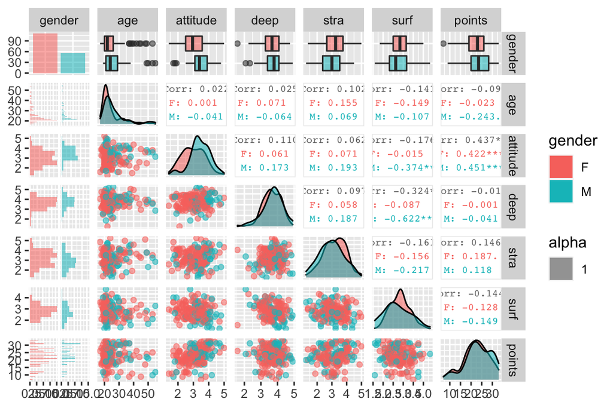

```r
# Load the required packages
library(ggplot2)
library(GGally, quietly=TRUE)
# Create the summary plot
p <- ggpairs(learning2014, mapping=aes(col=gender, alpha=1), legend=1,
             upper=list(continuous=wrap("cor", size=2.5)),
             lower=list(combo=wrap(ggally_facethist, binwidth=0.5)))
```

The above summary graph matrix contains several components in which the respondents are separated by their gender. In the diagonal, we first have a bar plot expressing the distribution of males and females: apparently there are almost twice as many females as there are males. The rest of the diagonal shows density diagrams expressing an estimate of continuous density of the observations based on the sample. For the variables age, deep, and points, the distributions are rather similar for both genders. It appears, however, that males got on average more points on attitude, while females scored more in strategic learning and surface learning. Moreover, most of the distributions seem non-Gaussian. Particularly the age distribution is very skewed due to the larger number of young than old respondents. These distributions are presented in an alternative way as histograms in the first column of the graph matrix and also as boxplots in the first row of the graph matrix.

Excluding the first column and row, the lower triangular of the graph matrix contains 2D scatter plots between all the numeric variables and the upper triangular the sample correlations. Linear relations (i.e. correlations) between individual variables are mostly quite week, expect that there is relatively high correlation between attitude and points for both females and males. There is also large negative correlation between surface learning and attitude as well as between surface learning and deep learning for males only. The negative correlation between age and points for males seems also notable as there is practically no correlation for females. This could be, however, because of the relatively small number of old males as each of them then has relatively large influence of the sample correlation. This can be checked by calculating the sample correlation between age and points for males of age less than 40:

```r
cor(subset(learning2014, gender == "M" & age < 40, select=c("age", "points")))[1, 2]
```

```
## [1] 0.1032825
```

which is slightly positive and thus confirms our suspicions. The rest of the linear relations between the pairs of variables are mostly relatively similar to males and females, although there are some smaller differences.

To examine the distributions and their normality when the observations are not separated by gender, we plot histograms of the numeric variables and on top of them draw a graph of the density of the normal distribution estimated for the sample.

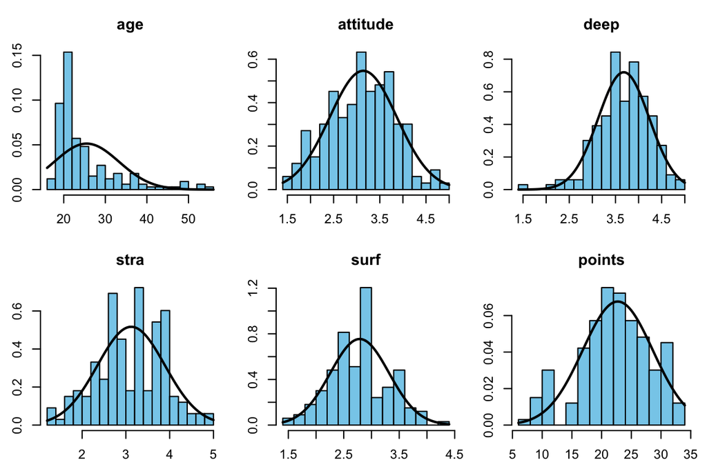

```r
par(mfrow=c(2, 3), mar=c(2.6, 2.6, 3, 1)) # Set graphical parameters
for(i1 in 2:ncol(learning2014)) { # Go through the numerical variables
  dat <- learning2014[,i1]
  tmp <- hist(dat, col="skyblue", breaks=15, freq=FALSE,
              main=colnames(learning2014[i1]))
  x <- seq(from=min(tmp$breaks), to=max(tmp$breaks), length.out=200)
  lines(x=x, y=dnorm(x, mean=mean(dat), sd=sd(dat)), lwd=2)
}
```

As expected, the overall age distribution is skewed. However, for attitude and deep learning the overall distribution somewhat resembles the normal distribution. Strategic learning, surface learning, and exam points are not either very far from Gaussianity when one accounts for the discrete nature of histograms in that the shape of the distribution is to some extend affected by the number of breaks.

We are interested in modelling linear relations of the exam points to the other variables. A suitable method is therefore a linear regression model of the form $y_i = \beta_0 + \beta_1x_{i1} + \cdots + \beta_Kx_{iK} + \varepsilon_i$ where $y_i$ is the $i$th observation, $x_{ik}$ is the corresponding $k$th explanatory variable, $\varepsilon_i$ is an error term, and $\beta_0,...,\beta_K$ are regression coefficients. The model is estimated by finding values for $\beta_0,...,\beta_K$, say $b_0,...,b_K$, such that the sum of squared residuals is minimized. The residuals are defined as $y_i - \hat{y}_i$ where $\hat{y}_i \equiv b_0 + b_1x_{i1} + \cdots + b_Kx_{iK}$ is the fitted value.

For constructing a linear model to explain variations in the exam points, our strategy is to find explanatory variables that have strong linear relation to the points variable. Based on the above summary graph matrix, attitude is the first choice. We also include strategic learning and surface learning as for both of them the sample correlation to points is larger than for the other continuous variables. These three variables also carry the advantage that the correlations are similar for males and females, implying that we most likely don’t need separate regression lines (or hyperplanes) for different genders. Particularly we are leaving out age from the regression as the correlation to points is quite different for males and females, while the negative correlation of males is mainly attributed to the relatively poorly scoring small group of old male respondents.

Below, we estimate the model and examine its summary statistics:

```r
m1 <- lm(points ~ attitude + stra + surf, data=learning2014)
summary(m1)
```

```
##
## Call:
## lm(formula = points ~ attitude + stra + surf, data = learning2014)
##
## Residuals:
##      Min       1Q   Median       3Q      Max
## -17.1550  -3.4346   0.5156   3.6401  10.8952
##
## Coefficients:
##             Estimate Std. Error t value Pr(>|t|)
## (Intercept)  11.0171     3.6837   2.991  0.00322 **
## attitude      3.3952     0.5741   5.913 1.93e-08 ***
## stra          0.8531     0.5416   1.575  0.11716
## surf         -0.5861     0.8014  -0.731  0.46563
## ---
## Signif. codes:  0 '***' 0.001 '**' 0.01 '*' 0.05 '.' 0.1 ' ' 1
##
## Residual standard error: 5.296 on 162 degrees of freedom
## Multiple R-squared:  0.2074, Adjusted R-squared:  0.1927
## F-statistic: 14.13 on 3 and 162 DF,  p-value: 3.156e-08
```

The estimate for the intercept parameter is approximately $11$, meaning that without any points from attutitude, strategic learning, or surface learning, the model predicts $11$ points from the exam. The estimate for the slope parameter of attitude is approximately $3.40$. The model therefore predicts that, ceteris paribus, scoring one extra point from attitude increases exam points by $3.40$. Similarly an extra point in strategic learning predicts $0.85$ points more in the exam and surface learning $0.59$ points less.

The $t$-tests, for which the $p$-values are given above in the right-most column under the headline “coefficients”, test the null hypothesis that the true regression coefficient is zero. The tests are valid in finite (i.e. “small”) samples if conditionally on the regressors, the errors are independently and jointly normally distributed with zero mean and common variance. Asymptotically (i.e. in “large” samples), the tests are valid under more relaxed conditions, however. The $p$-value expresses the probability of observing a sample that is as or more deviant from null than the observed data if the null is true. Small $p$-values can thereby be considered as evidence against the null hypothesis, at least as long as the assumptions required for the validity of the test are satisfied. That is, the intercept parameter and the slope parameter for attitude are most likely not zero ($p$-values are less than $0.01$), whereas for the slope parameters of stra and surf we cannot reject the hypothesis that they are zero ($p$-values are larger than $0.05$).

The $F$-test, for which the results are presented in the bottom row of the summary print, tests the null hypothesis that all the non-intercept regression coefficients are zero (in general, $F$-test can be used to test other hypotheses as well, however). The $p$-value is very small, so all the slope coefficients are most likely not zero. Based on the above discussion on the $t$-tests, one of the non-zero slope coefficients seems to be the one of attitude.

Because the coefficient for surface learning obtained the highest $p$-value from the $t$-test and surface learning does not have a statistically significant relation exam points when also relations to attitude and strategic learning are accounted for, we reduce the variable from the model, re-estimate, and check the summary statistics again:

```r
m2 <- update(m1, ~ .-surf)
summary(m2)
```

```
##
## Call:
## lm(formula = points ~ attitude + stra, data = learning2014)
##
## Residuals:
##      Min       1Q   Median       3Q      Max
## -17.6436  -3.3113   0.5575   3.7928  10.9295
##
## Coefficients:
##             Estimate Std. Error t value Pr(>|t|)
## (Intercept)   8.9729     2.3959   3.745  0.00025 ***
## attitude      3.4658     0.5652   6.132 6.31e-09 ***
## stra          0.9137     0.5345   1.709  0.08927 .
## ---
## Signif. codes:  0 '***' 0.001 '**' 0.01 '*' 0.05 '.' 0.1 ' ' 1
##
## Residual standard error: 5.289 on 163 degrees of freedom
## Multiple R-squared:  0.2048, Adjusted R-squared:  0.1951
## F-statistic: 20.99 on 2 and 163 DF,  p-value: 7.734e-09
```

As is shown in the above summary print, when surface learning was removed from the explanatory variables, strategic learning became statistically more significant. The $p$-value of the $t$-test is still more than $0.05$ but as it is less than $0.1$, strategic learning has some statistical significance in this model and we don’t therefore remove it. Compared to the previous model with also surface learning as a regressor, an extra point in attitude or strategic learning now predicts approximately $0.07$ or $0.06$ exam points more. That is, ceteris paribus, one more point in attitude now predicts $3.47$ exam points more and strategic learning $0.91$ points. These two variables became (statistically) more significant after removing surface learning, which is negatively correlated with points, from the model because they are both negatively correlated with it, and therefore some of their relation to exam points was attributed to the surface learning in the larger model. Another way to look at it is that some of surface learning’s relation to exam points is now attributed to attitude and strategic learning.

The intercept parameter estimate got smaller and it is now approximately $9$. The model therefore predicts $9$ points in the exam for a student that has zero points in attitude and strategic learning. The multiple R-squared statistic tells what portion of the variation in the exam points can be explained by variation in the explanatory variables, attitude and strategic learning. The value is $0.20$ so our model is able to explain one fifth of the variation in the exam points.

Next, we examine residual plots in order to evaluate how well the model assumptions are satisfied.

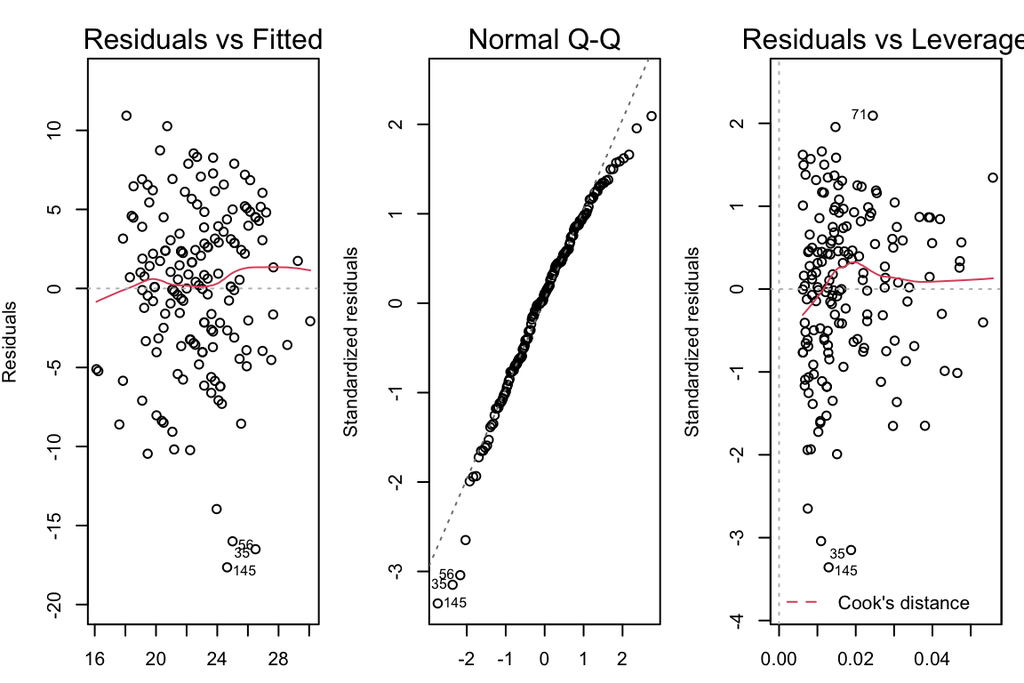

```r
par(mfrow=c(1, 3), mar=c(2.6, 3.9, 2.6, 1))
plot(m2, which=c(1, 2, 5))
```

First, examine the figure of the left which shows the scatter plot of the residuals against the fitted values. Residuals are the empirical counterparts of the error terms, defined as the differences between the observations and fitted values. A residual in the zero line implies that the corresponding observation is equal to the fitted value and deviation from the zero line gives the observation’s deviation from the fitted value. The red curvy line is a smoother that helps in discovering patterns in the residuals. If the relationship between the variables is linear, the smoother should be an approximately straight horizontal line passing through origo, which it is, at least to some extend. The assumption of constant error variance (conditionally on the regressors) implies that there should not be any apparent changes in the variation of the residuals. There is slightly smaller variance at the end and the four largest negative residuals appear as larger variance just before the reduction in the variance, so the assumption of constant variance is not perfectly satisfied. Overall, the defects don’t seem very serious, however.

The figure in the middle is normal QQ plot in which the sample quantiles of standardized residuals (standardized by dividing by their estimated standard errors) are plotted against the theoretical quantiles of standard normal distribution. If the errors are normally distributed, the points in the plot should all fall approximately on the straight dashed line (if the errors are independently and identically normally distributed, the standardized residuals actually follow a Student’s $t$ distribution. When sample size is large, the shape of the $t$-distribution does not deviate much from standard normal, however). This is not exactly the case above: it seems that there are too much too small residuals and not enough large residuals. That is, the sample distribution of the residuals is skewed to the left and it has too fat lower tail but not fat enough upper tail. Nonetheless, the sample distribution seems normal enough to have some faith in the statistical tests discussed above.

Finally, on the right we have the figure of standardized residuals plotted against their leverage. The leverage on the $x$-axis measures how influential the observations corresponding to the residuals are in the ordinary least squares estimation: observations with larger influence affect the coefficient estimates more. Thus, if there are large residuals with large influence, they may significantly distort the regression line (or hyperplane - in our case a regression plane as there are two explanatory variables) from where it would be without the outlier(s). The red curve in the figure is a smoother that helps to detect patterns in the residuals. It should be an approximately straight horizontal line passing through origo to implicate that there are no distorting observations. Is can be seen, there is a small group of large negative residuals deviating from others but fortunately they are not very influential. The smoother seems also straight enough, so we may conclude that there does not seem to be very problematic influential outliers. In summary, the overall fit of the model and validity of the assumption of linear relationships and jointly normal independent errors with common variance seems reasonable but possibly not exactly satisfied.

# Logistic regression

We consider a cross-sectional alcohol consumption data collected by schools reports questionnaires from Portuguese math and Portuguese language student’s and it contains 370 observations for 35 variables. Our dataset is constructed by joining the data from math and Portuguese language student’s so that only individuals that participated both classes are included. The aata contains several variables which are printed out below:

```r
# Read the data from Reijo Sund's github, as discussed in forum (370 observations, not 382):
alc <- readr::read_csv("https://github.com/rsund/IODS-project/raw/master/data/alc.csv")
alc <- alc[,-c(28:30, 37:48, 51)] # Remove the unnecessary variables
colnames(alc)
```

```
##  [1] "school"     "sex"        "age"        "address"    "famsize"
##  [6] "Pstatus"    "Medu"       "Fedu"       "Mjob"       "Fjob"
## [11] "reason"     "guardian"   "traveltime" "studytime"  "schoolsup"
## [16] "famsup"     "activities" "nursery"    "higher"     "internet"
## [21] "romantic"   "famrel"     "freetime"   "goout"      "Dalc"
## [26] "Walc"       "health"     "failures"   "paid"       "absences"
## [31] "G1"         "G2"         "G3"         "alc_use"    "high_use"
```

The variable alc_use is mean of daily (Dalc) and weekly (Walc) usages (in the scale 1-5) and the variable “high_use” is a logical indicator stating whether the variable alc_use takes a value larger than 2. The other variables include backround variables and well as the number of past class failures (failures) grades from the courses (G1 first period grade, G2 second period grade, G3 final grade). The full details about the data are available online at: https://archive.ics.uci.edu/ml/datasets/Student+Performance.

Before fitting the model, we examine the relations graphically. With the binary response variable, it seems appropriate the use boxplots that show summaries the distributions of the explanatory variables separately for students with high and low alcohol usage. The boxplots are presented below.

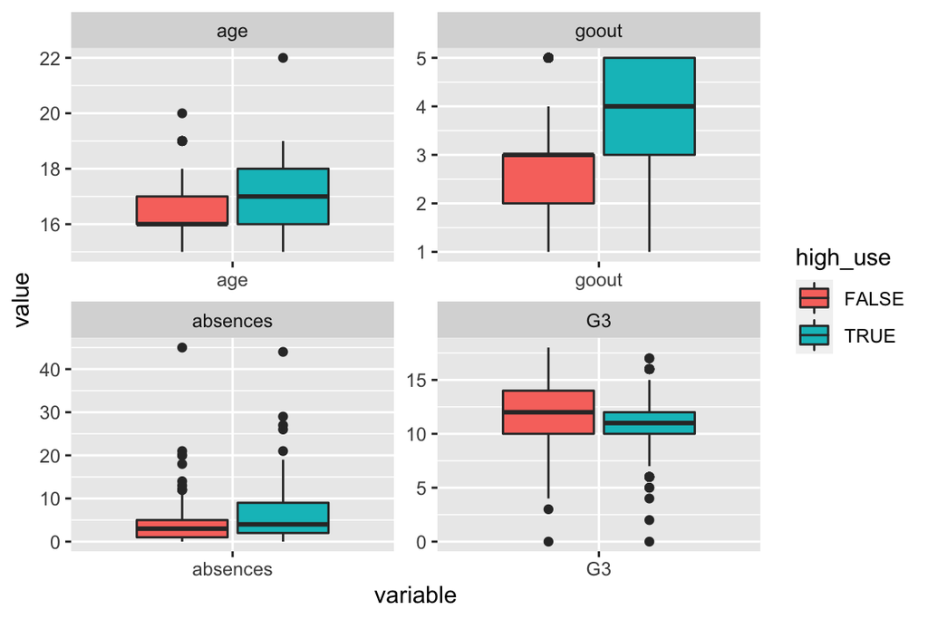

```r
# Load the required packages
library(dplyr)
library(ggplot2)
library(GGally, quietly=TRUE)
library(reshape2)

# Reform the data to produce the boxplots and then plot them.
alc_melt <- melt(alc[,colnames(alc) %in% c("age","goout", "absences", "G3", "high_use")], id.var="high_use")
p <- ggplot(data = alc_melt, aes(x=variable, y=value)) + geom_boxplot(aes(fill=high_use))
p + facet_wrap( ~ variable, scales="free")
```

As can be seen from the upper-left boxplot above, it appears that older students tend to drink more as suspected: the median age of high usage students is 17 while that is also the third age quartile of low usage students. Moreover, there seems to be only two low-usage respondents that are 19 or older. There seems to be even stronger relation between going out a lot with friends and alcohol usage (upper-right boxplot) which is in line with our hypothesis. In the scale 1-5 (1 low, 5 high) 75% of low usage students go out with intensity at most 3 while 75% of high usage students go out with intensity at least 3. As the lower-left boxplot presents, the larger number of absences seems to also be related to high usage of alcohol, as our hypothesis predicted. The relation is not however as strong as with going out with friends. Finally, the lower-right box shows that high usage of alcohol seems to be related slightly lower final grade, contradicting our earlier prediction. While this result might seem unintuitive at first, it could be that the negative relation is due to that high-performing students don’t drink that much in first place because of some common characteristic and not because drinking lot of alcohol makes you perform worse at school. Overall, 30% of the respondents is reported to have high alcohol usage, leaving 70% low usage respondents, as is calculated below.

```r
mean(alc_melt$high_use)
```

```
## [1] 0.3
```

Because the going out variables takes only five possible values, it might be appropriate to model it as a factor. Consequently, a more appropriate summary than a boxplot is a cross-tabulation. Below, the frequencies are scaled to relative proportions in the high/low usage groups.

```r
round(with(alc, table(goout, high_use)/c(rep(sum(!high_use), times=5), rep(sum(high_use), times=5))), 2)
```

```
##      high_use
## goout FALSE TRUE
##     1  0.07 0.03
##     2  0.32 0.14
##     3  0.37 0.21
##     4  0.15 0.34
##     5  0.08 0.29
```

As can be seen above, most of the low usage students go out with intensity 2 or 3 but most of the high usage student’s with intensity 4 or 5. Clearly students that go out a lot with friends have high usage of alcohol more often the ones who don’t go out with friends so very often.

Having, studied summaries of the data, we shall next fit the logistic regression model. We treat the variables absences, age, and grade are continuous but goout as factor. Below are the summary statistics.

```r
fit <- glm(high_use ~ age + absences + G3 + factor(goout) - 1, data=alc, family="binomial")
summary(fit)
```

```
##
## Call:
## glm(formula = high_use ~ age + absences + G3 + factor(goout) -
##     1, family = "binomial", data = alc)
##
## Deviance Residuals:
##     Min       1Q   Median       3Q      Max
## -1.8620  -0.6728  -0.5569   0.9506   2.1353
##
## Coefficients:
##                Estimate Std. Error z value Pr(>|z|)
## age             0.03994    0.11158   0.358  0.72036
## absences        0.07162    0.02248   3.186  0.00144 **
## G3             -0.04262    0.03968  -1.074  0.28279
## factor(goout)1 -2.57231    2.06715  -1.244  0.21336
## factor(goout)2 -2.12631    1.96217  -1.084  0.27852
## factor(goout)3 -1.93761    1.98297  -0.977  0.32851
## factor(goout)4 -0.60269    2.00219  -0.301  0.76340
## factor(goout)5 -0.22310    1.98633  -0.112  0.91057
## ---
## Signif. codes:  0 '***' 0.001 '**' 0.01 '*' 0.05 '.' 0.1 ' ' 1
##
## (Dispersion parameter for binomial family taken to be 1)
##
##     Null deviance: 512.93  on 370  degrees of freedom
## Residual deviance: 384.19  on 362  degrees of freedom
## AIC: 400.19
##
## Number of Fisher Scoring iterations: 4
```

Our logistic regression model is of the form
$$\begin{align*}
\text{logit}(Pr(\text{high_use})) =&\beta_1\text{age} + \beta_2\text{absences} + \beta_3\text{G3} + \beta_4 \boldsymbol{1}\lbrace \text{goout}=1 \rbrace + \beta_5 \boldsymbol{1}\lbrace \text{goout}=2 \rbrace + \beta_6 \boldsymbol{1}\lbrace \text{goout}=3 \rbrace \\
&+ \beta_7 \boldsymbol{1}\lbrace \text{goout}=4 \rbrace + \beta_8 \boldsymbol{1}\lbrace \text{goout}=5 \rbrace
\end{align*}$$
where $logit(p)=\log(p/(1-p))$ is the logit function (the inverse of the logistic function) and $\boldsymbol{1}\lbrace \text{goout}=i \rbrace$ is an indicator function that takes value one if $\text{goout}=i$ and zero otherwise. The regression coefficients and their estimates can thereby be interpreted as how much a unit increase in the corresponding explanatory variable increases the log-odds, in our case, the log-odds of student having a high alcohol usage.

For the goout variable we have five different coefficients: one for each answer in the scale 1-5. The interpretation is that the students in different goout classes have different intercepts - the log-odds the model predicts for a student with value zero for age, absences, and G3. Of course, predicting high alcohol usage for students that are zero years old is not sensible, so the interpretation is merely a theoretical one. A more practical interpretation is that a student with smaller intercept has smaller log-odds for high alcohol usage than a student who has the same values of age, absences, and G3, but larger intercept.

The odds-ratio is defined as
$$\frac{p_1/(1-p_1)}{p_2/(1-p_2)}$$
where $p_j$ is the probability of high alcohol usage in group $j$. By taking logarithm we obtain
$$\log\frac{p_1/(1-p_1)}{p_2/(1-p_2)} = \log\frac{p_1}{1-p_1} - \log\frac{p_2}{1-p_2},$$
that is, the log-odds-ratio is positive if and only if the log-odds with $p_1$ is higher than the log-odds with $p_2$. This implies that the odds-ratio is more than one if and only if the log-odds with $p_1$ is higher than the log-odds with $p_2$.

In terms of odds-ratio, the parameters of the model are therefore interpreted as follows. If the coefficient is positive (negative), then increasing the value of the corresponding variables makes the odds-ratio larger (less) than one when an individual with the increased (decreased) parameter value represents group 1 (with $p_1$ above) and an individual with the original value represents group 2 (with $p_2$ above). That is, the relative odds of having high use of alcohol increases (decreases).

Based on the above discussion on interpretation of the parameters, according our estimated model, larger age or more absences increases the odds of having high alcohol usage. This is in line with out hypotheses and the discussion related to graphical summaries of the data. Higher final grade (G3) decreases the odds, which is line with graphical summary but contradicts our hypothesis. For the going out variable (goout), it seems that the coefficient is larger the more often student goes out with friends. This means that the odds of high alcohol consumption is estimated to be larger for students who go out more, as was predicted by our hypothesis and by the graphical summary.

To get the coefficient estimates for odds, exponent of the estimates needs to be taken, as the following shows. By taking exponent of the model equation $\log(p/(1-p)) = \beta_1x_1 + \cdots + \beta_8x_8$ where $x_1,..,x_8$ are the regressors, we obtain the model for the odds as
$$p/(1-p) = (e^{\beta_1})^{x_1} \cdots (e^{\beta_8})^{x_8}$$
so the exponents of the coefficients are interpreted as the exponent bases for the explanatory variables.

Dividing the model implied odds for students with certain characteristics (group 1 with probability of high alcohol usage $p_1$) by odds for students with different characteristics (group 2 with probability of high alcohl usage $p_2$) then gives the model for odds-ratio as
$$\frac{p_1/(1-p_1)}{p_2/(1-p_2)} = (e^{\beta_1})^{(x_1^{(1)} - x_1^{(2)})} \cdots (e^{\beta_8})^{(x_8^{(1)} - x_8^{(2)})}$$
where $x_i^{(j)$ is the value of the $i$th explanatory variable in group $j$. Consequently, exponents of the coefficients are then also the coefficients for the model for the odds-ratio. In the above odds-ratio model, the interpretation of the coefficients is just for the difference between the values of the explanatory values in the two groups and not for the values themselves, and similarly to the model for odds they are interpreted as exponent bases for the (differences between) explanatory variables. Below, we calculate the exponents of the coefficients of the log-odds model (and thus obtain the coefficients for both, the odds model and the odds-ratio model) and calculate confidence intervals for the exponents coefficients.

```r
exp_coefs <- exp(coef(fit))
ci_exp_coefs <- exp(confint(fit))
round(cbind(exp_coefs, ci_exp_coefs), 3)
```

```
##                exp_coefs 2.5 % 97.5 %
## age                1.041 0.836  1.296
## absences           1.074 1.030  1.126
## G3                 0.958 0.886  1.036
## factor(goout)1     0.076 0.001  4.250
## factor(goout)2     0.119 0.002  5.514
## factor(goout)3     0.144 0.003  6.963
## factor(goout)4     0.547 0.011 27.937
## factor(goout)5     0.800 0.016 39.940
```

Next, we shall study the model’s predictive power on the low/high alcohol usage. Before that, we exclude the statistically non-signigicant variables from the model. According to the t-tests, age and G3 are not significant so we remove them. The t-tests don’t either give statistical significance for the five intercepts. However, one needs to careful when interpreting the tests for the factor intercepts, because the test is for the null of the coefficient being zero, not for the null whether the groups are different to each other. To investigate more, we fit a new model with age and G3 removed and now including an intercept and in doing so the intercept parameter becomes the intercept for the variable going out at intensity one.

```r
fit2 <- glm(high_use ~ absences + factor(goout), data=alc, family="binomial")
summary(fit2)
```

```
##
## Call:
## glm(formula = high_use ~ absences + factor(goout), family = "binomial",
##     data = alc)
##
## Deviance Residuals:
##     Min       1Q   Median       3Q      Max
## -1.8698  -0.6623  -0.5568   0.9296   2.1596
##
## Coefficients:
##                Estimate Std. Error z value Pr(>|z|)
## (Intercept)    -2.37793    0.69537  -3.420 0.000627 ***
## absences        0.07409    0.02239   3.309 0.000937 ***
## factor(goout)2  0.38302    0.73393   0.522 0.601761
## factor(goout)3  0.59236    0.71646   0.827 0.408354
## factor(goout)4  1.95585    0.71438   2.738 0.006185 **
## factor(goout)5  2.37879    0.73265   3.247 0.001167 **
## ---
## Signif. codes:  0 '***' 0.001 '**' 0.01 '*' 0.05 '.' 0.1 ' ' 1
##
## (Dispersion parameter for binomial family taken to be 1)
##
##     Null deviance: 452.04  on 369  degrees of freedom
## Residual deviance: 385.61  on 364  degrees of freedom
## AIC: 397.61
##
## Number of Fisher Scoring iterations: 4
```

As can be seen from the above summary printout, the intercept and factors for going out at intensities 4 and 5 became statistically significant. This was not due to excluding some of the variables but because the interpretation of the goout factors is now relative to group one and the difference relative to group one is statistically significant as it is far apart from zero. If one adds together the intercept and the coefficient for $\text{goout}=4$ or $5$, it can be found that the intercepts for groups 4 and 5 are also in this model close to zero.

To study how well the model predicts high alcohol usage, we calculate the predicted probabilities and then assume that model predicts high usage if the probability is more than $0.5$. After that, it can be calculated what is the average probability for the model to predict correctly. The cases of high/low use are tabulated below with the predictions:

```r
probs <- predict(fit2, type="response")
alc <- mutate(alc, probability=probs) %>% mutate(prediction = probability > 0.5)
(mytab <- with(alc, table(high_use, prediction)) %>% prop.table %>% addmargins)
```

```
##         prediction
## high_use      FALSE       TRUE        Sum
##    FALSE 0.61621622 0.08378378 0.70000000
##    TRUE  0.16486486 0.13513514 0.30000000
##    Sum   0.78108108 0.21891892 1.00000000
```

As shown above, according to the predictions of our model, $78\%$ of the respondents are low alcohol users while $70\%$ of the respondents are actually low alcohol users. Similarly, our model predicts high usage for $22\%$ of the respondents while $30\%$ are actually high users. The model in data camp predicts that $90\%$ of the users are low alcohol users and $10\%$ high. Although the data in datacamp is slightly different, the relative proportions of high/low alcohol users are approximately same, so our model is much better according to this in-sample prediction criteria.

The total portion of inaccurately classified individuals is in our model:

```r
with(alc, mean(!high_use - !prediction))
```

```
## [1] 0.2486486
```

That is, approximately $25\%$.

Finally, we do a 10-fold cross-validation in order to further compare our model to the data camp model:

```r
library(boot)
set.seed(1)
loss_func <- function(class, prob) mean(abs(class - prob) > 0.5)
cv <- cv.glm(data = alc, cost = loss_func, glmfit = fit2, K = 10)
cv$delta[1] # average number of wrong predictions in the cross validation
```

```
## [1] 0.2702703
```

The error-portion is slightly higher than the data camp model (approximately $0.27$ when it is approximately $0.26$ in the data camp model) but with different random number generator seeds the error is sometimes close $0.26$ so there is no big difference in performance according to this out-of-sample prediction criteria.

# Clustering and classification

We consider a cross-sectional dataset containing housing values in suburbs of Boston. Each observation unit is a suburb/town and for each suburb there are different statistics such as per capita crime rate (“crim”), nitrogen oxides concentration (“nox”), average number of rooms per dwelling (“rm”), and more. The full is of variables and their descriptions are available through the command `help("Boston", package="MASS")`. The data (called “Boston”) is also inspected below.

```r
library(MASS) # Load the package MASS
data(Boston) # Load the data Boston (from the package MASS) to global environment
str(Boston)
```

```
## 'data.frame':    506 obs. of  14 variables:
##  $ crim   : num  0.00632 0.02731 0.02729 0.03237 0.06905 ...
##  $ zn     : num  18 0 0 0 0 0 12.5 12.5 12.5 12.5 ...
##  $ indus  : num  2.31 7.07 7.07 2.18 2.18 2.18 7.87 7.87 7.87 7.87 ...
##  $ chas   : int  0 0 0 0 0 0 0 0 0 0 ...
##  $ nox    : num  0.538 0.469 0.469 0.458 0.458 0.458 0.524 0.524 0.524 0.524 ...
##  $ rm     : num  6.58 6.42 7.18 7 7.15 ...
##  $ age    : num  65.2 78.9 61.1 45.8 54.2 58.7 66.6 96.1 100 85.9 ...
##  $ dis    : num  4.09 4.97 4.97 6.06 6.06 ...
##  $ rad    : int  1 2 2 3 3 3 5 5 5 5 ...
##  $ tax    : num  296 242 242 222 222 222 311 311 311 311 ...
##  $ ptratio: num  15.3 17.8 17.8 18.7 18.7 18.7 15.2 15.2 15.2 15.2 ...
##  $ black  : num  397 397 393 395 397 ...
##  $ lstat  : num  4.98 9.14 4.03 2.94 5.33 ...
##  $ medv   : num  24 21.6 34.7 33.4 36.2 28.7 22.9 27.1 16.5 18.9 ...
```

As can be seen from above, the data consists of 506 towns for each of which there are 14 different statistics recorded.

All the variables are numeric so a decent graphical summary is obtained by drawing a scatter plot matrix. We include an OLS estimated regression line in each scatter plot in the upper-right triangle to get an idea of possible linear relationships, and instead of repeating the scatter plots in the lower-left triangle, we present the sample correlations.

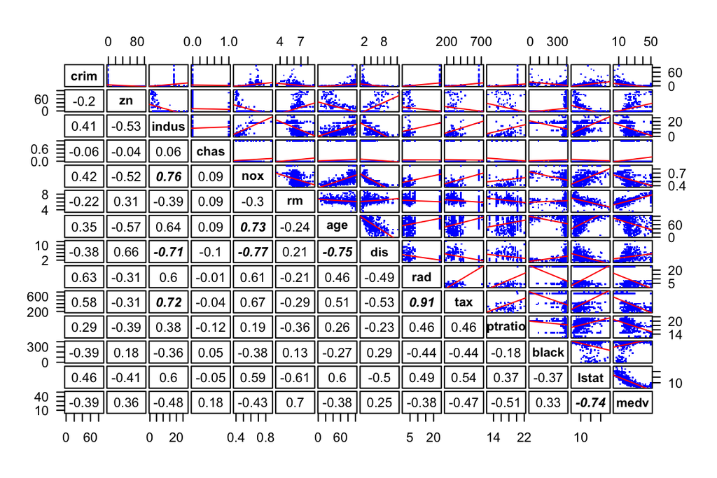

```r
par(las=1)
pairs(Boston, gap=0.2, font.labels=2, upper.panel=function(x, y) {
  points(x, y, col="blue", pch=".", cex=1.5)
  abline(lm(y ~ x), col="red")
  },
  lower.panel=function(x, y) {
    old_par <- par(no.readonly=TRUE)
    on.exit(old_par)
    par(usr=c(0, 1, 0, 1))
    text(x=0.5, y=0.5, labels=round(cor(x, y), 2), font=ifelse(abs(cor(x, y))>0.7, 4, 1))
  })
```

Interpreting the summary figure above, the sample correlations and the regression lines reveal possible linear relations among the variables, as long the scatter plots themselves don’t indicate that the relation is unlinear. Some of the linear relations are rather strong in that the correlation between the variables is more than 0.7 in absolute value. Such high correlations are bolded in the above figure and the highest correlation (0.91) is found between variables rad (index of accessibility to radial highways) and tax (full-value property-tax rate per $10,000.). This high correlations, however, seems to be because of the two clusters being mainly in the opposite corners, while the cluster in the upper-right corner (high tax and high rad) contains notable less observations than the other cluster in the lower-left corner. Sample correlation does not therefore give a good summary of the relationship that is better explained with the two clusters.

Some clusters of observation units can be detected form the data. For instance, rad seems to be either small or large and tax is either low, medium-low, or high. The variable chas indicates clustering at the first look as well but it is actually an indicator variable so the “clusters” are not really clusters.

In order to examine distributions of the variables, we shall draw their histograms (scaled to density distributions) together with estimated standard normal density graph.

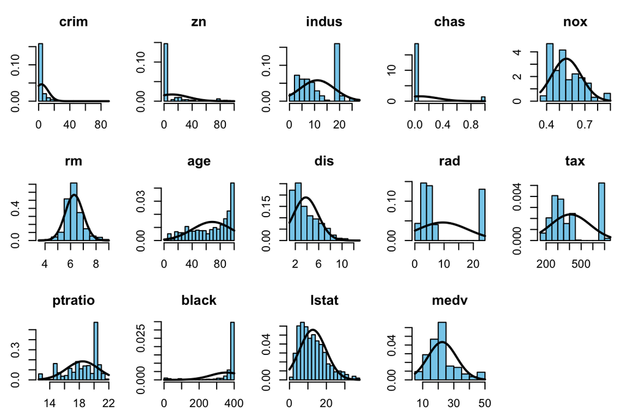

```r
par(mfrow=c(3, 5), mar=c(2.6, 2.6, 3, 1)) # Set graphical parameters
for(i1 in 1:ncol(Boston)) { # Go through the variables
  dat <- Boston[,i1]
  tmp <- hist(dat, col="skyblue", breaks=15, freq=FALSE,
              main=colnames(Boston[i1]))
  x <- seq(from=min(tmp$breaks), to=max(tmp$breaks), length.out=200)
  lines(x=x, y=dnorm(x, mean=mean(dat), sd=sd(dat)), lwd=2)
}
```

The above histograms confirm our findings of the clustering in rad and tax variables. Besides the variable rm, all the distributions seem strongly non-Gaussian. For instance, the crime rate (crim) distribution is very skewed to the right with lots of towns associated with low crimes rates and not so many with relatively large crime rates.

Our goal is to classify and cluster the observations. The employed methods, linear discriminant analysis and k-means clustering, use the distance of the observations to various points in doing so, so the data should be standardized in a way that all the variables are in the same scale. We thereby center the data about zero and divide each variable by the sample standard errors. After scaling the variables, a summary of the scaled data is presented.

```r
boston_scaled <- as.data.frame(scale(Boston))
summary(boston_scaled)
```

```
##       crim                 zn               indus              chas
##  Min.   :-0.419367   Min.   :-0.48724   Min.   :-1.5563   Min.   :-0.2723
##  1st Qu.:-0.410563   1st Qu.:-0.48724   1st Qu.:-0.8668   1st Qu.:-0.2723
##  Median :-0.390280   Median :-0.48724   Median :-0.2109   Median :-0.2723
##  Mean   : 0.000000   Mean   : 0.00000   Mean   : 0.0000   Mean   : 0.0000
##  3rd Qu.: 0.007389   3rd Qu.: 0.04872   3rd Qu.: 1.0150   3rd Qu.:-0.2723
##  Max.   : 9.924110   Max.   : 3.80047   Max.   : 2.4202   Max.   : 3.6648
##       nox                rm               age               dis
##  Min.   :-1.4644   Min.   :-3.8764   Min.   :-2.3331   Min.   :-1.2658
##  1st Qu.:-0.9121   1st Qu.:-0.5681   1st Qu.:-0.8366   1st Qu.:-0.8049
##  Median :-0.1441   Median :-0.1084   Median : 0.3171   Median :-0.2790
##  Mean   : 0.0000   Mean   : 0.0000   Mean   : 0.0000   Mean   : 0.0000
##  3rd Qu.: 0.5981   3rd Qu.: 0.4823   3rd Qu.: 0.9059   3rd Qu.: 0.6617
##  Max.   : 2.7296   Max.   : 3.5515   Max.   : 1.1164   Max.   : 3.9566
##       rad               tax             ptratio            black
##  Min.   :-0.9819   Min.   :-1.3127   Min.   :-2.7047   Min.   :-3.9033
##  1st Qu.:-0.6373   1st Qu.:-0.7668   1st Qu.:-0.4876   1st Qu.: 0.2049
##  Median :-0.5225   Median :-0.4642   Median : 0.2746   Median : 0.3808
##  Mean   : 0.0000   Mean   : 0.0000   Mean   : 0.0000   Mean   : 0.0000
##  3rd Qu.: 1.6596   3rd Qu.: 1.5294   3rd Qu.: 0.8058   3rd Qu.: 0.4332
##  Max.   : 1.6596   Max.   : 1.7964   Max.   : 1.6372   Max.   : 0.4406
##      lstat              medv
##  Min.   :-1.5296   Min.   :-1.9063
##  1st Qu.:-0.7986   1st Qu.:-0.5989
##  Median :-0.1811   Median :-0.1449
##  Mean   : 0.0000   Mean   : 0.0000
##  3rd Qu.: 0.6024   3rd Qu.: 0.2683
##  Max.   : 3.5453   Max.   : 2.9865
```

```r
apply(boston_scaled, 2, var) # Sample variance of each variable
```

```
##    crim      zn   indus    chas     nox      rm     age     dis     rad     tax
##       1       1       1       1       1       1       1       1       1       1
## ptratio   black   lstat    medv
##       1       1       1       1
```

As the above summary shows, the sample mean of each variable is now zero. Also, the sample variance is one.

We want to classify the towns according to their crime rates using linear discriminant analysis (LDA). Therefore, we need to create a categorical type variable from the crime rate that defines the classes to which towns will be assigned: we use sample quantiles as the break points because then by construction there will be (at least almost) equal amounts of observations in each category. After that, we drop the old crime rate variable from the data and add the categorical rate to replace it. Finally, we randomly divide the data into train (80% of towns) and test (20% of towns) sets so that we may evaluate how well our model predicts the crime rate categories in the test set based on estimation on the train set.

```r
library(dplyr)
crime <- with(boston_scaled, cut(crim, breaks = quantile(crim), include.lowest = TRUE, label=c("low", "med_low", "med_high", "high")))
boston_scaled <- dplyr::select(boston_scaled, -crim) %>% cbind(crime)
which_train <- sample(nrow(boston_scaled), size=0.8*nrow(boston_scaled), replace=FALSE)
train <- boston_scaled[which_train,]
test <- boston_scaled[-which_train,]
```

```r
fit <- lda(crime ~. -chas, data=boston_scaled)
```

And then draw the LDA biplot:

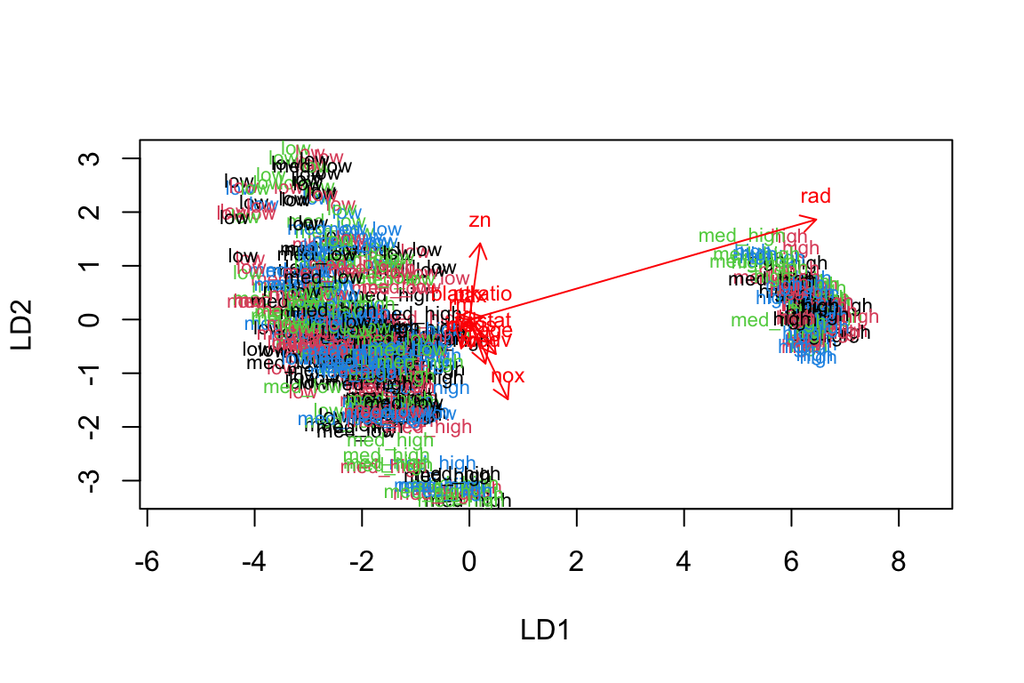

```r
# the function for lda biplot arrows
lda.arrows <- function(x, myscale = 2, arrow_heads = 0.1, color = "red", tex = 0.75, choices = c(1,2)){
  heads <- coef(x)
  arrows(x0 = 0, y0 = 0,
         x1 = myscale * heads[,choices[1]],
         y1 = myscale * heads[,choices[2]], col=color, length = arrow_heads)
  text(myscale * heads[,choices], labels = row.names(heads),
       cex = tex, col=color, pos=3)
}
classes <- as.numeric(train$crime) # Classifications of the observations
plot(fit, dimen=2, col=classes, pch=classes) # LDA biplot without arrows
lda.arrows(fit, myscale = 2) # Add the arrows
```

The arrows in the above LDA biplot are determined by the coefficients in the LDA model. A larger coefficient (in absolute value) implies a longer arrow.

```r
classes_test <- test$crime
test <- dplyr::select(test, -crime)
pred <- predict(fit, newdata=test)
table(correct=classes_test, predicted=pred$class)
```

```
##           predicted
## correct    low med_low med_high high
##   low       15       9        0    0
##   med_low    3      21        3    0
##   med_high   0      11       18    0
##   high       0       0        1   21
```

The above tabulation shows the correct test data classes against the predicted ones. Overall, the performance seems reasonable but especially many of the low crime rate towns were inaccurately classified as med_low crime rate towns and many of the med_high towns were incorrectly classified as med_low towns. The high crime rate tows were, however, predicted almost perfectly: all except one high crime town were classified as high crime towns and no town that does not have high crime rate was classified as high crime town.

We then cluster the observations with the k-means algorithm; that is, we do not specify beforehand any classes for the observations but let the algorithm to find clusters. For that, we create a new standardized data set that contains all the original variables, then run the k-means algorithm with it using different numbers of clusters, and examine the total within cluster sums of squares.

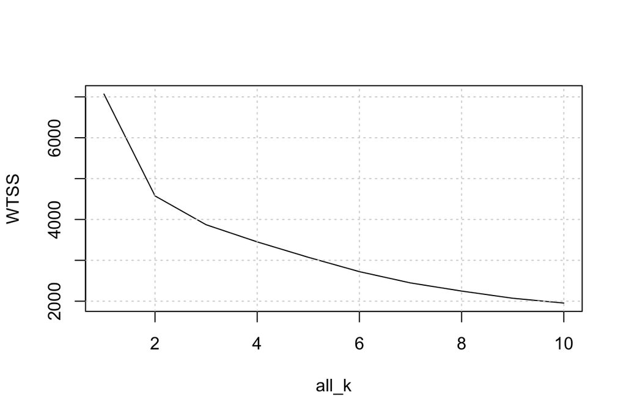

```r
# data(Boston) # It is useless to reload the same data again when we did not change it.
boston_scaled2 <- as.data.frame(scale(Boston))
dist_eu <- dist(boston_scaled2, method="euclidean") # Calculate (eucledian) distances between the observations as said in the assignment (this seems rather random and unrelated, though)
set.seed(1) # Initialize the random number generator
all_k <- 1:10
all_km <- lapply(all_k, function(k) kmeans(boston_scaled2, centers=k, nstart=10))
plot(sapply(all_k, function(i1) all_km[[i1]]$tot.withinss) ~ all_k, type="l", ylab="WTSS")
grid()
```

The above figure presents the total within cluster sums of squares (TWSS) with different numbers of clusters. We want to select a number of clusters so that the TWSS is as small as possible compared to the number of clusters and therefore a number of clusters such that smaller number induces significantly larger TWSS and larger number not so significantly smaller TWSS is a good choice. Based on the above figure, a good number of clusters is therefore two.

The two clusters can be visualized in a scatter plot matrix as:

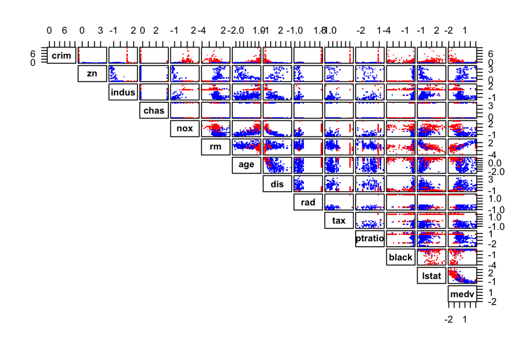

```r
par(las=1)
nk <- 2
pairs(boston_scaled2, gap=0.2, font.labels=2, upper.panel=function(x, y) {
  points(x, y, col=c("blue", "red")[all_km[[nk]]$cluster], pch=".", cex=1.5)
  }, lower.panel=NULL)
```

The figure shows that the variables rad and tax are mainly clustered to a clusters of low and high values, as was they would probably individually cluster as well. The other variables seems to be also clustered to clusters of observations that are close to each other: there is not so much mixing of red and blue colors in the scatter plots. Often the clusters are not just virtually separated but also exhibit common patterns. For example, in the first row of the scatter plot matrix, the red dots (observations in the second cluster) are often in a vertical line or scattered, while the blue dots (observations in the first cluster) are in a horizontal line in the bottom. That is, first cluster contains towns with very low crime rate while the second cluster contains the rest. One disappointment, however, is that the dummy variable chas did not cluster into zero and ones but instead there are ones and zeros in both clusters.